# Was the 2025–26 Knicks Championship a Fluke?

Simulating the NBA season with two Bradley-Terry models

# Executive Summary

The New York Knicks won the 2026 NBA championship, their first title since 1973. Was that the sign of a truly dominant team, or did the bounces simply go their way? A single season shows only one version of events, so we replayed the 2025–26 season on a computer 100,000 times, with every regular-season game, the play-in tournament, and every playoff series decided by chance and counted how often the Knicks came out on top.

To decide how likely each team is to win any given game, we built two forecasting models from the final score of every regular-season game.

- **The first model gives every team one overall strength rating**, plus a bonus for playing at home. It treats a team’s quality as fixed all year.
- **The second model does not use a fixed rating.** It tracks how many points each team has recently been scoring and allowing, counting recent games more heavily, and updates after every game, so hot and cold streaks carry over into later games. It also gives each team a lasting rating for what scoring misses, such as winning close games. Its playoffs are played game by game, so ratings keep updating within a series.

On games they had not seen (the final fifth of the regular season), each model picked about 78% of winners correctly, compared with about 60% if we only knew who was at home. The two were essentially tied.

**What we found.** The Knicks won 53 games and finished third in the East, behind Detroit and Boston. That is about what their play deserved: they average roughly 52 wins in the replays. Their championship chances were much smaller. The Knicks won the title in 3.2% of replays under the first model (about 1 in 31) and 6.6% under the second (about 1 in 15), making them the fifth most likely champion among 30 teams under both. Oklahoma City, with the most wins (64), was the favorite at 37% and 19%.

**What this means.** Winning a title takes four best-of-seven series, so even the best team usually fails. In a typical replay, the champion is a team with title chances no better than the Knicks’ about 14% of the time under the first model and 35% under the second. Our verdict: the Knicks’ title was a long shot, but not a fluke. Results like it happen in a sizeable minority of seasons.

**Caveats.** The models know only final scores and home court, not injuries, trades, or rest. The second model spreads title chances more evenly than the first, which partly explains its higher odds for the Knicks, because its replayed seasons are less spread out between strong and weak teams than the real standings were. We could not check the playoff updating against real playoff data.

# Technical Report

The report proceeds in two moves. The first builds and checks the tool: the data, the two forecasting models, and the checks that they give trustworthy probabilities. The second uses it: the simulation replays the season and estimates the probabilities of the events of interest, returning to the Knicks’ championship in particular. Each results section ends by connecting its numbers back to those events.

## Problem and Motivation

A championship is a rare, high-variance event. Even a very good team has to win four consecutive best-of-seven series, and each game is a noisy contest, so the best team in the league wins the title far less than half of the time. This makes “the Knicks won” hard to interpret on its own: was it the expected outcome for a team of their quality, or a long shot that happened to come through?

We tackle this with **simulation**. If we have a model that gives the probability that either team wins any game, we can use it to play the entire season, the play-in tournament, and the playoffs again and again. The share of replays in which an event happens estimates its probability. The advantage of simulation over looking at one game at a time is that we can estimate probabilities of complicated events, such as winning the title or meeting a particular opponent in the Finals, that depend on dozens of games.

The model at the center of our approach is the **Bradley-Terry model**, which compares two teams head to head. We follow Lectures 12 and 13: each team gets a latent strength $\lambda_j$, and the log-odds that team $H$ beats team $A$ are the difference in strengths, with an extra term $\lambda_0$ for a home-court advantage:

$$\operatorname{logit} \mathbb{P}(H \text{ beats } A) = \lambda_0 \cdot \mathbb{1}\{H \text{ at home}\} + \lambda_H - \lambda_A .$$

We compare two ways of defining the strengths.

1. **Model 1 (team strengths).** Each team has its own fixed $\lambda_j$ for the whole season (Lecture 13). This is the standard model.
2. **Model 2 (dynamic offense/defense plus a team effect).** A team’s strength is built from how well it has been scoring and defending *so far*, so it changes from game to game, plus a lasting team-specific term for quality that scoring does not capture:
   $$\lambda_j(t) = \beta_O \, O_j(t) + \beta_D \, D_j(t) + u_j, \qquad u_j \sim N(0, \tau^2),$$
   where $O_j(t)$ and $D_j(t)$ are team $j$’s offensive and defensive scores going into game $t$, and $u_j$ is a random team effect. This is the “strengths depend on covariates, plus a team-specific intercept” extension discussed in the project description. In the simulation, Model 2 also keeps updating the scores through the playoffs.

Comparing the two tells us whether the Knicks’ title odds depend on assuming a fixed rating, and whether letting momentum and team-specific quality matter changes the picture.

### Events of interest

The assignment asks for probabilities of complex events rather than single-game outcomes. We estimate:

- **The Knicks’ regular season:** their number of wins and their rank in the East, compared with what actually happened.
- **The Knicks’ playoff run:** the probability they win the East and the probability they win the title, along with how those depend on their seed.
- **The championship race:** the probability that each team wins the title, and the probability of specific Finals matchups (“Team A and Team B reach the Finals and Team A wins”).
- **Team seeding:** how likely each team is to land in each playoff seed.
- **An anomaly measure:** how often a typical season’s champion has title odds no better than the Knicks’ did.

## Data

We use the 2025–26 NBA schedule and results from the `hoopR` package, which collects ESPN’s schedule data. Each row is a game with a date, home and away teams, and final scores.

### Settings

All settings are collected here so that the analysis can be re-run with different choices.

```r
N_SIMS             <- 100000    # simulated seasons per model; the assignment recommends >= 10,000
SEED               <- 2026
CHUNK              <- 1000      # simulations processed at a time (to limit memory use)
PARAM_UNCERTAINTY  <- TRUE      # draw model parameters from their sampling distribution each time
SEASON             <- 2026      # hoopR convention: 2026 = the 2025-26 season
FOCUS_TEAM         <- "New York Knicks"

# Model 2 ("dynamic" scores); explained in the "Features" section
HALF_LIFE          <- 20        # a game's weight halves after this many of the team's later games
PRIOR_GAMES        <- 8         # shrinkage toward average: equal to this many "average" games
TEST_FRAC          <- 0.20      # last 20% of the regular season held out for evaluation

GAMES_CSV          <- "data/nba_games.csv"      # CSV with columns date, home, away, home_pts, away_pts, neutral.
dir.create("data", showWarnings = FALSE)
SIMS_FILE          <- "data/nba_sims_2026.rds"
RERUN_SIMS         <- FALSE     # FALSE: reuse the saved simulations if the file exists
```

```r
library(dplyr)
library(tidyr)
library(ggplot2)
library(scales)
library(knitr)
# Install once if needed: install.packages(c("BradleyTerry2", "hoopR", "readr"))
```

### The 30 teams

We need each team’s conference, because playoff seeding happens within a conference. Teams are sorted alphabetically so that every team has a fixed numeric `id` (used to index the simulation arrays).

```r
teams <- tibble::tribble(
  ~team,                     ~conf,
  "Atlanta Hawks",           "East", "Boston Celtics",          "East",
  "Brooklyn Nets",           "East", "Charlotte Hornets",       "East",
  "Chicago Bulls",           "East", "Cleveland Cavaliers",     "East",
  "Detroit Pistons",         "East", "Indiana Pacers",          "East",
  "Miami Heat",              "East", "Milwaukee Bucks",         "East",
  "New York Knicks",         "East", "Orlando Magic",           "East",
  "Philadelphia 76ers",      "East", "Toronto Raptors",         "East",
  "Washington Wizards",      "East",
  "Dallas Mavericks",        "West", "Denver Nuggets",          "West",
  "Golden State Warriors",   "West", "Houston Rockets",         "West",
  "LA Clippers",             "West", "Los Angeles Lakers",      "West",
  "Memphis Grizzlies",       "West", "Minnesota Timberwolves",  "West",
  "New Orleans Pelicans",    "West", "Oklahoma City Thunder",   "West",
  "Phoenix Suns",            "West", "Portland Trail Blazers",  "West",
  "Sacramento Kings",        "West", "San Antonio Spurs",       "West",
  "Utah Jazz",               "West"
) |>
  arrange(team) |>
  mutate(id = row_number(), conf_id = if_else(conf == "East", 1L, 2L))

n_teams <- nrow(teams)
stopifnot(n_teams == 30)
```

### Downloading and cleaning the games

The ESPN feed is not a clean list of the 82-game seasons, so several kinds of rows have to be removed before any model is fit. Fitting a Bradley-Terry model to the wrong games would distort the team ratings, and, because the simulation replays the actual schedule, it would also give teams the wrong number of games. We pay extra attention on these.

- **All-Star weekend games and the NBA Cup championship game** are tagged as regular season in the feed but do not count toward the 82 games. (The Cup group-stage games and the Cup quarterfinals and semifinals *do* count, so they stay.)
- **Postponed games** leave a 0–0 placeholder row at the original date, and the real result appears again in a separate “makeup” row. We drop the placeholders so that each game is counted once.
- **Neutral-site games** (the NBA games in Mexico City, Berlin, and London, and the NBA Cup semifinals in Las Vegas; five games in all) have no true home team. Following Lecture 13, we flag them with an indicator so that the home-court term only applies to games at a team’s own arena.

```r
fix_names <- function(x) recode(x, "Los Angeles Clippers" = "LA Clippers")
cleaning_log <- NULL

if (!is.null(GAMES_CSV)) {
  games <- readr::read_csv(GAMES_CSV, show_col_types = FALSE)
  if (!"neutral" %in% names(games)) games$neutral <- FALSE
  if (!"date"    %in% names(games)) games$date    <- seq_len(nrow(games))
  games$date <- as.Date(games$date)
} else {
  raw <- hoopR::load_nba_schedule(seasons = SEASON)
  if (!"neutral_site" %in% names(raw)) raw$neutral_site <- FALSE
  reg <- raw |> filter(season_type == 2) |> arrange(game_date, game_id)    # 2 = regular season

  is_excl <- grepl("Cup Championship|All-Star", reg$notes_headline, ignore.case = TRUE) |
             reg$type_abbreviation %in% c("CC", "ALLSTAR")
  is_placeholder <- !is_excl & (is.na(reg$home_score) | is.na(reg$away_score) |
                      as.numeric(reg$home_score) + as.numeric(reg$away_score) == 0)

  cleaning_log <- tibble(
    Step = c("Rows tagged as regular season in the feed",
             "Removed: All-Star games and NBA Cup championship",
             "Removed: 0-0 placeholder rows for postponed games"),
    Rows = c(nrow(reg), sum(is_excl), sum(is_placeholder)))

  games <- reg[!is_excl & !is_placeholder, ] |>
    transmute(date = as.Date(game_date),
              home = home_display_name, away = away_display_name,
              home_pts = as.numeric(home_score), away_pts = as.numeric(away_score),
              neutral = coalesce(as.logical(neutral_site), FALSE) |
                grepl("Berlin|London|Mexico|Paris", notes_headline))
}

games <- games |> mutate(home = fix_names(home), away = fix_names(away))

# Drop anything that is not a game between two NBA teams (e.g. "Team Stripes", "World")
is_real <- games$home %in% teams$team & games$away %in% teams$team
if (!is.null(cleaning_log)) {
  cleaning_log <- bind_rows(cleaning_log,
    tibble(Step = "Removed: games not between two NBA teams", Rows = sum(!is_real)))
}

games <- games[is_real, ] |>
  mutate(ord = row_number()) |>
  arrange(date, ord) |>                       # chronological order (stable within a date)
  left_join(teams |> select(team, home_id = id), by = c("home" = "team")) |>
  left_join(teams |> select(team, away_id = id), by = c("away" = "team")) |>
  mutate(home_win = as.integer(home_pts > away_pts),
         at_home  = if_else(neutral, 0L, 1L),   # 1 = home team at its own arena, 0 = neutral site
         game_no  = row_number())

if (!is.null(cleaning_log)) {
  cleaning_log <- bind_rows(cleaning_log, tibble(Step = "Games used in the analysis", Rows = nrow(games)))
  kable(cleaning_log, caption = "Cleaning steps and the number of rows affected by each")
}
```

An NBA regular season has $30 \times 82 / 2 = 1{,}230$ games with every team playing 82. We check this to make sure the cleaning worked.

```r
gp <- table(c(games$home_id, games$away_id))
if (nrow(games) != 1230 || any(gp != 82)) {
  warning("Expected 1,230 games and 82 per team, got ", nrow(games),
          " games (per team: ", min(gp), "-", max(gp), ").")
}
cat(nrow(games), "games;", sum(games$neutral), "at neutral sites; every team plays between",
    min(gp), "and", max(gp), "games.\n")
```

```
1230 games; 5 at neutral sites; every team plays between 82 and 82 games.
```

We also record each team’s actual record and conference rank, so we can compare our simulations with what really happened.

```r
actual <- bind_rows(
  games |> transmute(id = home_id, w = home_win),
  games |> transmute(id = away_id, w = 1L - home_win)
) |>
  group_by(id) |>
  summarise(actual_wins = sum(w), actual_losses = n() - sum(w), .groups = "drop") |>
  left_join(teams, by = "id") |>
  group_by(conf) |>
  mutate(actual_conf_rank = rank(-actual_wins, ties.method = "min")) |>   # wins only; no tiebreakers
  ungroup()

k_actual <- actual |> filter(team == FOCUS_TEAM)
```

The Knicks went 53–29 and finished number 3 in the Eastern Conference (ranked by wins only; official tiebreakers are not applied). Only Detroit (60 wins) and Boston (56) won more games in the East. In the whole league, Oklahoma City (64) and San Antonio (62) won the most.

## Features

The two models use different sets of inputs. We describe them here, with the reasoning behind each choice.

| Model | Input | What it is | Why we use it |
| --- | --- | --- | --- |
| 1 and 2 | Home court (`at.home`) | 1 if the home team plays at its own arena, 0 at a neutral site | The home team wins more often than the away team between equal teams. Neutral-site games are the control group that identifies this effect. |
| 1 | Team identity | One strength parameter per team (one reference team is fixed at 0, since only differences matter) | The standard Bradley-Terry setup, which lets us rank all 30 teams from head-to-head results. |
| 2 | Offensive score $O_j(t)$ | Team $j$’s recent points scored per game, relative to the league average | Scoring is the first half of what wins basketball games, and it changes during the season. |
| 2 | Defensive score $D_j(t)$ | Team $j$’s recent points *allowed* per game, relative to the league average (sign flipped so higher is better) | Defense is the second half. Keeping offense and defense separate lets us ask which matters more. |
| 2 | Team effect $u_j$ | A random intercept per team, shrunk toward zero | Captures lasting quality that scoring does not (for example close-game skill). Shrinkage keeps these 30 extra numbers from overfitting. |
| 2 | Scores updated in the playoffs | Playoff games are simulated with points, and the scores change after each game | Lets momentum within a series matter. This is a simulation feature, not a fitted input. |

### How the dynamic scores are built

We want Model 2’s inputs to reflect what a forecaster would have known *just before* each game, so that fitting the model does not use information from the future. For each team, we keep a running average of its points scored and allowed in its earlier games, with two refinements.

- **Recent games count more.** A game’s weight is cut in half for every `HALF_LIFE` = 20 of the team’s games after it. This lets the scores react to injuries, trades, and hot or cold stretches.
- **Early-season scores are shrunk toward average.** With only a few games played, a team’s averages are very noisy, so we add `PRIOR_GAMES` = 8 imaginary games at exactly league-average performance. As the season goes on, the real games dominate.

**Why eight games?** The number is a deliberate but simple choice, not something estimated from the data. It acts like a prior that starts each season at league average and fades as real games arrive: after $g$ games the imaginary average games still carry weight $8/(g+8)$, so they make up half the weight after 8 games and a quarter after 24. A much smaller number (say 1-2) would leave the first few scores jumpy, because one lopsided game could swing them a long way; a much larger number would pin the scores near 0 and stop them from reflecting actual play. Eight is roughly two weeks of an NBA schedule, long enough for real games to start dominating but short enough that the scores stay responsive. Like `HALF_LIFE`, this is a judgment call; choosing it by held-out log-loss is listed under Future Work.

Formally, with $x_k$ the points a team scored in its $k$-th earlier game, $a_k$ the number of that team’s games since then, and $\bar p$ the league-average points per team per game:

$$O_j(t)=\frac{\sum_{k<t} w_k\,(x_k-\bar p)}{\sum_{k<t} w_k + c},\qquad
D_j(t)=\frac{\sum_{k<t} w_k\,(\bar p - y_k)}{\sum_{k<t} w_k + c},\qquad
w_k = 0.5^{\,a_k/\text{half-life}},$$

where $y_k$ is the points the team allowed in game $k$ and $c$ is `PRIOR_GAMES`. Computing this is easy to do one game at a time: each team keeps two running totals, which are multiplied by $\rho = 0.5^{1/\text{half-life}}$ and then updated with the newest game.

```r
LEAGUE_MEAN <- mean(c(games$home_pts, games$away_pts))
rho         <- 0.5^(1 / HALF_LIFE)

dynamic_ratings <- function(gm) {
  n <- nrow(gm)
  S_off <- S_def <- W <- numeric(n_teams)
  pre <- matrix(0, n, 4, dimnames = list(NULL, c("off_h", "def_h", "off_a", "def_a")))
  for (k in seq_len(n)) {
    h <- gm$home_id[k]; a <- gm$away_id[k]
    # scores BEFORE the game (only earlier games are used)
    pre[k, ] <- c(S_off[h] / (W[h] + PRIOR_GAMES), S_def[h] / (W[h] + PRIOR_GAMES),
                  S_off[a] / (W[a] + PRIOR_GAMES), S_def[a] / (W[a] + PRIOR_GAMES))
    # then update both teams with this game's result
    S_off[h] <- rho * S_off[h] + (gm$home_pts[k] - LEAGUE_MEAN)
    S_def[h] <- rho * S_def[h] + (LEAGUE_MEAN - gm$away_pts[k])
    W[h]     <- rho * W[h] + 1
    S_off[a] <- rho * S_off[a] + (gm$away_pts[k] - LEAGUE_MEAN)
    S_def[a] <- rho * S_def[a] + (LEAGUE_MEAN - gm$home_pts[k])
    W[a]     <- rho * W[a] + 1
  }
  list(pre = tibble::as_tibble(pre),
       end = tibble(team_id = seq_len(n_teams),
                    off = S_off / (W + PRIOR_GAMES), def = S_def / (W + PRIOR_GAMES)))
}

dyn   <- dynamic_ratings(games)
games <- bind_cols(games, dyn$pre)
```

To see whether these scores behave sensibly, we plot them for the Knicks across their season. The point of this plot is to verify that the scores really *move* in ways that match the team’s season, since otherwise Model 2 would reduce to a fixed rating. We expect the scores to bounce around early (small samples, shrunk toward 0), then settle into a range that reflects the team’s true quality.

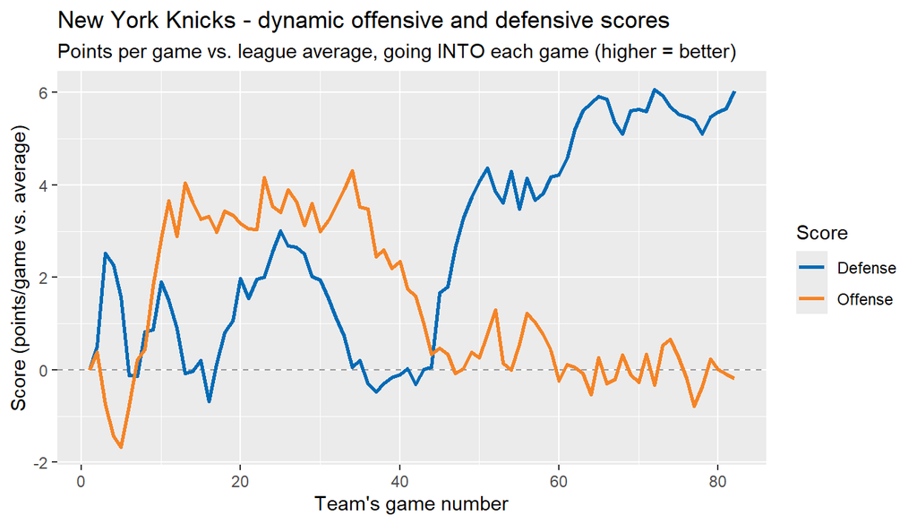

```r
knicks_dyn <- bind_rows(
  games |> transmute(team = home, game_no, Offense = off_h, Defense = def_h),
  games |> transmute(team = away, game_no, Offense = off_a, Defense = def_a)
) |>
  filter(team == FOCUS_TEAM) |>
  arrange(game_no) |>
  mutate(team_game = row_number()) |>
  pivot_longer(c(Offense, Defense), names_to = "Score", values_to = "value")

ggplot(knicks_dyn, aes(team_game, value, colour = Score)) +
  geom_hline(yintercept = 0, linetype = 2, colour = "grey60") +
  geom_line(linewidth = 0.9) +
  scale_colour_manual(values = c(Offense = "#F58426", Defense = "#006BB6")) +
  labs(title = paste(FOCUS_TEAM, "- dynamic offensive and defensive scores"),
       subtitle = "Points per game vs. league average, going INTO each game (higher = better)",
       x = "Team's game number", y = "Score (points/game vs. average)")
```

For the events of interest, the point of having two models is that they give two different, defensible views of the same season: one from a fixed strength rating, the other from how each team was actually playing. Both feed the same simulation.

## Evaluation Criteria

Our simulations only work if the models give good *probabilities*, not just good picks of the winner: a model that said “80%” for every game that was really 60% would pick winners fine but would badly distort every simulated season. We therefore evaluate with three measures.

- **Log-loss** (lower is better): the average negative log of the probability the model gave to what actually happened. It heavily penalizes confident wrong predictions.
- **Brier score** (lower is better): the average squared gap between the predicted probability and the 0/1 outcome.
- **Accuracy** (higher is better): the share of games where the team given more than a 50% chance won. We report it because it is easy to interpret, but it ignores how confident the model was.

```r
metrics_fun <- function(model, evaluation, p, y) {
  p <- pmin(pmax(unname(p), 1e-9), 1 - 1e-9)
  tibble(Evaluation = evaluation, Model = model,
         `Log-loss` = -mean(y * log(p) + (1 - y) * log(1 - p)),
         Brier      = mean((p - y)^2),
         Accuracy   = mean((p > 0.5) == y))
}
```

### Train/test split

We hold out the **last 20% of the regular season** (246 of the 1,230 games) and fit the models on the first 80% (984 games). We split by date, rather than at random, for two reasons. First, the goal is to forecast games that are in the future of the games the model has seen, which a random split does not mimic. Second, Model 2’s inputs depend on the order of games, so a random split would let the model “peek” at the future through the scores of games it was not supposed to see.

```r
n_train <- floor(nrow(games) * (1 - TEST_FRAC))
train <- games[seq_len(n_train), ]
test  <- games[-seq_len(n_train), ]
c(train_games = nrow(train), test_games = nrow(test),
  last_train_date = format(max(train$date)), first_test_date = format(min(test$date)))
```

```
    train_games      test_games last_train_date first_test_date
          "984"           "246"    "2026-03-12"    "2026-03-12"
```

## Models

### Model 1: team strengths + home court

We follow Lecture 13 closely. Games are grouped by (home team, away team, neutral-site flag) and the number of home wins and away wins in each group is passed to `BradleyTerry2::BTm`. The formula `~ team + at.home` asks for one strength per team and one home-court term. The first team alphabetically is the reference, with strength 0.

```r
fit_bt1 <- function(gm) {
  res <- gm |>
    group_by(home, away, at_home) |>
    summarise(home.win = sum(home_win), away.win = sum(1 - home_win), .groups = "drop")
  df <- data.frame(home.win = res$home.win, away.win = res$away.win)
  df$home.team <- data.frame(team = factor(res$home, levels = teams$team), at.home = res$at_home)
  df$away.team <- data.frame(team = factor(res$away, levels = teams$team), at.home = 0)
  BradleyTerry2::BTm(
    outcome = cbind(home.win, away.win),
    player1 = home.team, player2 = away.team,
    formula = ~ team + at.home,
    refcat  = teams$team[1],
    id      = "team",
    data    = df)
}

fit1        <- fit_bt1(games)
lambda_hat  <- BradleyTerry2::BTabilities(fit1)
lambda0_hat <- unname(coef(fit1)["at.home"])
```

The estimated home-court effect is $\hat\lambda_0 =$ 0.283 on the log-odds scale. For two equally strong teams, this means the home team wins about 57.0% of the time.

### Model 2: dynamic offense/defense + a team effect + home court

Model 2 builds a team’s strength from the dynamic scores described above, plus a team-specific term for anything the scores miss. Because the dynamic scores change from game to game, every game gets its own row in the data (instead of grouping). The data frame for each team carries the home-court indicator and its pre-game offensive and defensive scores. `BTm` automatically uses the *difference* in these inputs between the two teams.

**A team effect.** A strength made only of points scored and allowed cannot recognize a team that is better than its scoring suggests, for example one that wins a lot of close games. So we add a team-specific intercept $u_j$, which is the form suggested in the project description (covariates plus a team-specific intercept capturing everything the covariates do not):

$$\operatorname{logit} \mathbb{P}(H \text{ beats } A) = \lambda_0 \cdot \mathbb{1}\{H \text{ at home}\} + \beta_O\,[O_H(t) - O_A(t)] + \beta_D\,[D_H(t) - D_A(t)] + u_H - u_A, \qquad u_j \sim N(0, \tau^2).$$

The team effects are treated as random effects, so they are shrunk toward zero: a team only gets a large $u_j$ if the offense and defense scores clearly fail to explain how it did. In `BradleyTerry2` this is the formula `~ off_rtg + def_rtg + at.home + (1 | team)`. It is fit by penalized quasi-likelihood, the package’s method for random effects.

**Dynamic playoffs.** In the simulation, Model 2’s playoffs are played game by game with points, the same way as the regular season. After every playoff game, both teams’ offensive and defensive scores are updated, so a team that dominates the first two games of a series enters Game 3 with a higher rating, and a team that gets blown out enters with a lower one.

```r
fit_bt2 <- function(gm) {
  df <- data.frame(home.win = gm$home_win, away.win = 1 - gm$home_win)
  df$home.team <- data.frame(team = factor(gm$home, levels = teams$team), at.home = gm$at_home,
                             off_rtg = gm$off_h, def_rtg = gm$def_h)
  df$away.team <- data.frame(team = factor(gm$away, levels = teams$team), at.home = 0,
                             off_rtg = gm$off_a, def_rtg = gm$def_a)
  suppressWarnings(
    BradleyTerry2::BTm(
      outcome = cbind(home.win, away.win),
      player1 = home.team, player2 = away.team,
      formula = ~ off_rtg + def_rtg + at.home + (1 | team),
      id = "team", data = df))
}

# Estimated team effects u_j and an approximate covariance matrix for them (used to draw
# uncertain team effects in the simulation). Z has +1 for the home team and -1 for the away team.
team_effects <- function(fit, gm) {
  cf <- coef(fit); Z <- fit$random
  fixed <- cf["off_rtg"] * (gm$off_h - gm$off_a) + cf["def_rtg"] * (gm$def_h - gm$def_a) +
           cf["at.home"] * gm$at_home
  u <- as.vector(MASS::ginv(Z) %*% (fit$linear.predictors - fixed))
  w <- fit$fitted.values * (1 - fit$fitted.values)
  list(mean = u, cov = solve(crossprod(Z, Z * w) + diag(1 / fit$sigma^2, ncol(Z))))
}

fit2  <- fit_bt2(games)
cf2   <- coef(fit2)
V2    <- fit2$varFix; dimnames(V2) <- list(names(cf2), names(cf2))
U_cfg <- team_effects(fit2, games)

tibble(Term = c("Offensive score", "Defensive score", "Home court", "Team effect (SD, tau)"),
       Estimate = c(unname(cf2), fit2$sigma),
       `Std. error` = c(sqrt(diag(V2)), sqrt(fit2$varSigma))) |>
  kable(digits = 4, caption = "Model 2 estimates")
```

Model 2 estimates

| Term | Estimate | Std. error |
| --- | --- | --- |
| Offensive score | 0.1104 | 0.0221 |
| Defensive score | 0.1660 | 0.0180 |
| Home court | 0.2634 | 0.0637 |
| Team effect (SD, tau) | 0.2065 | 0.0656 |

```r
tibble(Team = teams$team, `Team effect (u)` = round(U_cfg$mean, 3)) |>
  arrange(desc(`Team effect (u)`)) |>
  filter(row_number() <= 5 | row_number() > n() - 5) |>
  kable(caption = "Teams with the five largest and five smallest team effects")
```

Teams with the five largest and five smallest team effects

| Team | Team effect (u) |
| --- | --- |
| San Antonio Spurs | 0.259 |
| Los Angeles Lakers | 0.246 |
| Denver Nuggets | 0.172 |
| Detroit Pistons | 0.128 |
| Cleveland Cavaliers | 0.119 |
| Golden State Warriors | -0.139 |
| Dallas Mavericks | -0.173 |
| Indiana Pacers | -0.210 |
| Brooklyn Nets | -0.257 |
| Memphis Grizzlies | -0.268 |

**How to read these tables.** Each coefficient is the change in the log-odds that the home team wins, for each additional point per game of that score *relative to the opponent*.

## Results: Do the Dynamic Scores Help?

We compare the two models with a “home court only” baseline that gives every game the same home-win probability. The in-sample numbers use every game; the **out-of-sample** numbers (models refit on the first 80% of the season, scored on the last 20%) are the fair comparison, because Model 1 has 30 free parameters, while Model 2 has 3 plus 30 shrunken team effects.

```r
pred_bt1 <- function(fit, gm) {
  ab <- BradleyTerry2::BTabilities(fit)[, "ability"]
  plogis(ab[gm$home] - ab[gm$away] + coef(fit)["at.home"] * gm$at_home)
}
pred_bt2 <- function(fit, gm_fit, gm_new) {            # team effects estimated on gm_fit
  cf <- coef(fit); u <- team_effects(fit, gm_fit)$mean
  plogis(cf["off_rtg"] * (gm_new$off_h - gm_new$off_a) + cf["def_rtg"] * (gm_new$def_h - gm_new$def_a) +
           cf["at.home"] * gm_new$at_home + u[gm_new$home_id] - u[gm_new$away_id])
}

fit1_tr <- fit_bt1(train); fit2_tr <- fit_bt2(train)
base_p  <- mean(train$home_win)

p1_all <- pred_bt1(fit1, games); p2_all <- pred_bt2(fit2, games, games)
p1_te  <- pred_bt1(fit1_tr, test); p2_te <- pred_bt2(fit2_tr, train, test)

cmp <- bind_rows(
  metrics_fun("Home court only",          "In-sample",     rep(mean(games$home_win), nrow(games)), games$home_win),
  metrics_fun("Model 1 (team strengths)", "In-sample",     p1_all, games$home_win),
  metrics_fun("Model 2 (dynamic scores + team effect)",         "In-sample",     p2_all, games$home_win),
  metrics_fun("Home court only",          "Out-of-sample", rep(base_p, nrow(test)), test$home_win),
  metrics_fun("Model 1 (team strengths)", "Out-of-sample", p1_te, test$home_win),
  metrics_fun("Model 2 (dynamic scores + team effect)",         "Out-of-sample", p2_te, test$home_win)
)
kable(cmp, digits = 4)
```

| Evaluation | Model | Log-loss | Brier | Accuracy |
| --- | --- | --- | --- | --- |
| In-sample | Home court only | 0.6872 | 0.2470 | 0.5545 |
| In-sample | Model 1 (team strengths) | 0.5685 | 0.1925 | 0.7114 |
| In-sample | Model 2 (dynamic scores + team effect) | 0.5827 | 0.1985 | 0.6967 |
| Out-of-sample | Home court only | 0.6799 | 0.2434 | 0.5976 |
| Out-of-sample | Model 1 (team strengths) | 0.5062 | 0.1650 | 0.7805 |
| Out-of-sample | Model 2 (dynamic scores + team effect) | 0.5052 | 0.1650 | 0.7846 |

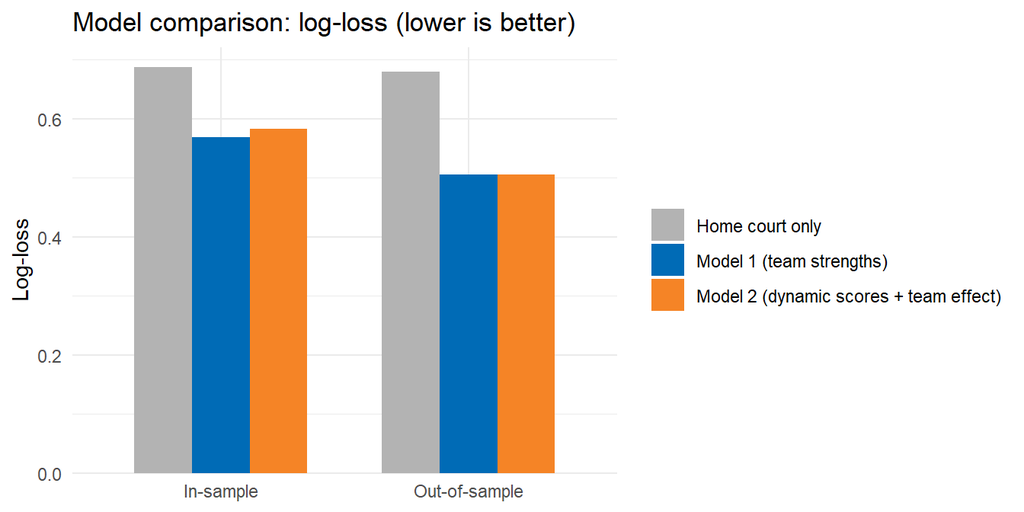

```r
cmp |>
  mutate(Evaluation = factor(Evaluation, levels = c("In-sample", "Out-of-sample"))) |>
  ggplot(aes(Evaluation, `Log-loss`, fill = Model)) +
  geom_col(position = "dodge", width = 0.7) +
  scale_fill_manual(values = c("Home court only" = "grey70",
                               "Model 1 (team strengths)" = "#006BB6",
                               "Model 2 (dynamic scores + team effect)" = "#F58426")) +
  scale_y_continuous(expand = expansion(mult = c(0, 0.05))) +
  labs(title = "Model comparison: log-loss (lower is better)",
       x = NULL, y = "Log-loss", fill = NULL) +
  theme_minimal()
```

The table gives the exact numbers and the figure below shows them side by side. The comparison tells us two things. First, in-sample, Model 1 fits the games it was trained on slightly better than Model 2 (log-loss 0.569 versus 0.583). Second, and more important, on the held-out games the two models are essentially tied: log-loss 0.5062 for Model 1 versus 0.5052 for Model 2, with accuracy of 78.0% and 78.5%. The difference is far smaller than the noise in about 250 test games, so we do not claim either model predicts better. Both are far better than the home-court-only baseline (log-loss 0.680, 59.8% accuracy), so both extract real information about team quality. Model 2 matches the 30-parameter model out of sample while using a team’s recent scoring and defense and a shrunken team effect, which supports using it as a second view of how strong each team was.

For the events of interest, this is the key result: because neither model can be dismissed out of sample, we report both, and the gap between what they say about the Knicks becomes part of the answer rather than a choice between two conflicting forecasts.

### Are the probabilities calibrated?

A model whose probabilities are right on average will, among games where it said “about 70%”, see the home team win about 70% of the time. This **calibration** is what the simulation needs. We sort the held-out games into five equal-sized groups by predicted home-win probability and compare the average prediction with the actual home win rate. Points near the dashed diagonal are well calibrated. With only about 250 games in the test set, each point is noisy, so we are looking for no systematic departure from the diagonal, not a perfect match.

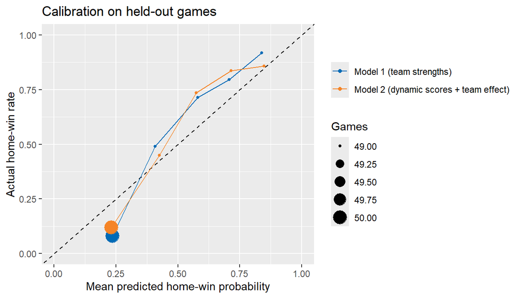

```r
make_calib <- function(y, p, model_name) {
  tibble(y = y, p = unname(p)) |>
    mutate(bin = ntile(p, 5)) |>
    group_by(bin) |>
    summarise(mean_pred = mean(p), actual_rate = mean(y), n = n(), .groups = "drop") |>
    mutate(model = model_name)
}
calib <- bind_rows(make_calib(test$home_win, p1_te, "Model 1 (team strengths)"),
                   make_calib(test$home_win, p2_te, "Model 2 (dynamic scores + team effect)"))

ggplot(calib, aes(mean_pred, actual_rate, colour = model)) +
  geom_abline(linetype = 2) +
  geom_line() + geom_point(aes(size = n)) +
  scale_colour_manual(values = c("#006BB6", "#F58426")) +
  coord_cartesian(xlim = c(0, 1), ylim = c(0, 1)) +
  labs(title = "Calibration on held-out games",
       x = "Mean predicted home-win probability", y = "Actual home-win rate",
       colour = NULL, size = "Games")
```

As a second check at the team level, we sum each model’s game probabilities into **expected wins** and compare them with each team’s actual wins. This asks whether the model recovers the standings.

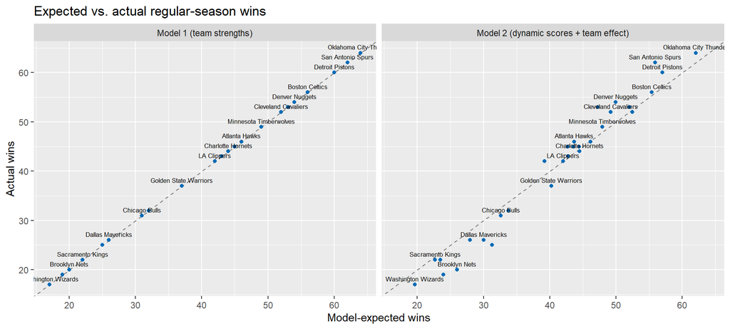

```r
exp_w <- function(p, gm) {
  bind_rows(tibble(id = gm$home_id, p = p), tibble(id = gm$away_id, p = 1 - p)) |>
    group_by(id) |> summarise(e = sum(p), .groups = "drop")
}
calib_t <- bind_rows(
  actual |> left_join(exp_w(p1_all, games), by = "id") |> mutate(model = "Model 1 (team strengths)"),
  actual |> left_join(exp_w(p2_all, games), by = "id") |> mutate(model = "Model 2 (dynamic scores + team effect)"))

ggplot(calib_t, aes(e, actual_wins, label = team)) +
  geom_abline(linetype = 2, colour = "grey50") +
  geom_point(colour = "#006BB6") +
  geom_text(size = 2.2, vjust = -0.7, check_overlap = TRUE) +
  facet_wrap(~model) +
  labs(x = "Model-expected wins", y = "Actual wins",
       title = "Expected vs. actual regular-season wins")
```

In the Model 1 panel every team sits exactly on the diagonal. That is not a test of the model: a Bradley-Terry fit of this kind reproduces each team’s actual win total exactly by construction, so the held-out calibration check above is the real test. Model 2 has no such guarantee, and its expected wins miss the actual totals by a typical 3.0 wins (at most 6.3 for the worst team), so it is the panel to study. Teams above the diagonal won more games than their scoring profile suggests, and teams below it won fewer. We return to these teams in the results below, since they are the “lucky” and “unlucky” teams of our simulation.

## Simulation Design

We now use the fitted models to replay the season. Both models feed the same bracket machinery, and they differ in how regular-season games are simulated and in whether scores keep updating in the playoffs. We describe the pieces in turn.

### What every simulated season includes

- **The regular season.** The actual 1,230-game schedule is played, with each game’s winner drawn from the model’s probability.
- **Seeding.** Within each conference, teams are ranked by wins. Ties are broken randomly (the official head-to-head and division tiebreakers are not implemented).
- **The play-in tournament.** Seeds 7 and 8 play each other, seeds 9 and 10 play each other, and the 7–8 loser plays the 9–10 winner for the last playoff spot.
- **The playoffs.** Four rounds of best-of-seven series in a 2-2-1-1-1 home/away pattern, with the higher seed hosting. The Finals’ home court goes to the team with more regular-season wins.
- **Parameter uncertainty.** The fitted parameters are only estimates, so each simulation draws its own parameters from a normal distribution centered at the estimates, using the estimated covariance matrix. Skipping this step would treat estimated team strengths as exactly known and make every simulated season more predictable than reality.

**Every simulation saves every team’s results**: wins, conference rank, playoff seed, and how many playoff rounds the team won. The simulated events in the results are then just counts from one large table.

### Shared playoff machinery

The code below simulates single games, best-of-seven series, and a conference bracket. They operate on vectors of teams, one entry per simulation, so thousands of simulations run at once.

```r
mvn_draw <- function(cf, V, n) {
  if (!PARAM_UNCERTAINTY) {
    B <- matrix(cf, length(cf), n)
  } else {
    L <- t(chol(V))
    B <- cf + L %*% matrix(rnorm(length(cf) * n), ncol = n)
  }
  rownames(B) <- names(cf)
  B
}

# --- one game: `home` and `away` are team-id vectors (length n) ---
# P is either list(h, Theta) (fixed strengths) or, for the fully dynamic playoffs, a list
# containing the running score state `E` (see "Fully dynamic playoffs" below).
play_game <- function(home, away, P) {
  if (!is.null(P$E)) return(dyn_game(home, away, P))
  n   <- length(home); idx <- seq_len(n)
  eta <- P$h + P$Theta[cbind(home, idx)] - P$Theta[cbind(away, idx)]
  ifelse(runif(n) < plogis(eta), home, away)
}

# --- best-of-7, team `a` has home court (games 1,2,5,7 at a) ---
play_series <- function(a, b, P) {
  if (!is.null(P$E)) return(dyn_series(a, b, P))
  n <- length(a); idx <- seq_len(n)
  d <- P$Theta[cbind(a, idx)] - P$Theta[cbind(b, idx)]
  a_home <- c(TRUE, TRUE, FALSE, FALSE, TRUE, FALSE, TRUE)
  wins_a <- 0
  # Playing all 7 games and checking for >= 4 wins gives the same winner distribution
  # as stopping once a team reaches 4.
  for (g in 1:7) wins_a <- wins_a + (runif(n) < plogis(d + if (a_home[g]) P$h else -P$h))
  ifelse(wins_a >= 4, a, b)
}

# --- series where home court goes to the lower "seed score" ---
series_by_seed <- function(t1, s1, t2, s2, P) {
  swap <- s2 < s1
  a <- ifelse(swap, t2, t1); b <- ifelse(swap, t1, t2)
  w <- play_series(a, b, P)
  t1_won <- w == t1
  list(win = w, win_seed = ifelse(t1_won, s1, s2), lose = ifelse(t1_won, t2, t1))
}

# --- one conference: play-in + 4 rounds. S: 15 x n matrix of team ids ordered by rank ---
sim_conference <- function(S, P, rounds_won, playoff_seed) {
  n <- ncol(S); idx <- seq_len(n)
  rec <- function(mat, team, value) { mat[cbind(team, idx)] <- value; mat }

  w78  <- play_game(S[7, ], S[8, ], P)
  l78  <- ifelse(w78 == S[7, ], S[8, ], S[7, ])
  w910 <- play_game(S[9, ], S[10, ], P)
  g3   <- play_game(l78, w910, P)
  T8   <- rbind(S[1:6, , drop = FALSE], w78, g3)          # row = playoff seed (1..8)
  for (s in 1:8) playoff_seed <- rec(playoff_seed, T8[s, ], s)

  seed_score <- function(s) rep(s, n)
  a <- series_by_seed(T8[1, ], seed_score(1), T8[8, ], seed_score(8), P)
  b <- series_by_seed(T8[4, ], seed_score(4), T8[5, ], seed_score(5), P)
  c <- series_by_seed(T8[3, ], seed_score(3), T8[6, ], seed_score(6), P)
  d <- series_by_seed(T8[2, ], seed_score(2), T8[7, ], seed_score(7), P)
  for (x in list(a, b, c, d)) rounds_won <- rec(rounds_won, x$lose, 0L)
  e <- series_by_seed(a$win, a$win_seed, b$win, b$win_seed, P)
  f <- series_by_seed(c$win, c$win_seed, d$win, d$win_seed, P)
  for (x in list(e, f)) rounds_won <- rec(rounds_won, x$lose, 1L)
  g <- series_by_seed(e$win, e$win_seed, f$win, f$win_seed, P)
  rounds_won <- rec(rounds_won, g$lose, 2L)

  list(champ = g$win, rounds_won = rounds_won, playoff_seed = playoff_seed)
}
```

### Model 1’s regular season

For Model 1, every simulation draws its own team strengths $\lambda_j$ and home advantage $\lambda_0$, then plays all 1,230 games at once.

```r
cf1 <- coef(fit1); V1 <- vcov(fit1)

regseason_bt1 <- function(n) {
  B <- mvn_draw(cf1, V1, n)
  P <- list(h = B["at.home", ],
            Theta = rbind(0, B[paste0("team", teams$team[-1]), , drop = FALSE]))   # 30 x n (ref team = 0)
  eta <- P$Theta[games$home_id, , drop = FALSE] - P$Theta[games$away_id, , drop = FALSE] +
         outer(games$at_home, P$h)
  list(home_win = matrix(runif(length(eta)) < plogis(eta), nrow = nrow(eta)), P = P)
}
```

### Model 2’s regular season (the dynamic part)

Model 2 is harder to simulate, because each game’s probability depends on the teams’ scores, and those scores depend on the *points* scored in the simulated games before it. So the simulated season has to be played in order, and it needs simulated points as well as simulated winners.

To produce points, we fit a simple points model to the real games,

$$\text{pts} = \mu + \eta\cdot\mathbb{1}\{\text{home}\} + a_i + d_j + \varepsilon,\qquad \varepsilon\sim N(0,\sigma^2),$$

where $a_i$ is team $i$’s true scoring level and $d_j$ is how much its opponent tends to allow. Each simulated game then proceeds in four steps.

1. **Compute the win probability** from the two teams’ *current simulated* offensive and defensive scores (the Model 2 formula).
2. **Draw the winner** from that probability.
3. **Draw points consistent with the winner.** The final margin comes from the points model but is restricted to have the sign of the winner (a truncated normal), and the combined score comes from the points model. This makes the points a team scores and allows agree with the result.
4. **Update both teams’ scores** using those points, ready for the next game.

A good or bad run therefore feeds into later games, exactly as in the real data. Each simulation also draws a set of team effects $u_j$ (from the estimated effects and their approximate uncertainty), which are added to every game’s log-odds, and the playoffs keep updating the scores (next subsection). For speed, games are processed in “batches” in which no team plays twice. This is exactly equivalent to going one game at a time, because a team’s scores depend only on that team’s own earlier games.

```r
# ---- points model (used only to generate points in the Model 2 simulation) ----
pts_long <- bind_rows(
  games |> transmute(pts = home_pts, is_home = at_home,
                     off_team = factor(home, levels = teams$team), def_opp = factor(away, levels = teams$team)),
  games |> transmute(pts = away_pts, is_home = 0L,
                     off_team = factor(away, levels = teams$team), def_opp = factor(home, levels = teams$team))
)
fit_pts   <- lm(pts ~ is_home + off_team + def_opp, data = pts_long)
sigma_pts <- sigma(fit_pts)
cfp <- coef(fit_pts); Vp <- vcov(fit_pts)

# ---- chronological batches: every team appears at most once per batch ----
make_batches <- function(gm) {
  last <- integer(n_teams); b <- integer(nrow(gm))
  for (k in seq_len(nrow(gm))) {
    bk <- max(last[gm$home_id[k]], last[gm$away_id[k]]) + 1L
    b[k] <- bk; last[gm$home_id[k]] <- bk; last[gm$away_id[k]] <- bk
  }
  unname(split(seq_len(nrow(gm)), b))
}
batches <- make_batches(games)

cs <- function(M, v) M * rep(v, each = nrow(M))        # multiply column j of M by v[j]

# --- regular season for every model that uses dynamic scores ---
# cf, V: fixed-effect estimates and covariance; Ucfg: team effects (NULL = none);
# dynamic_playoffs: TRUE = keep updating the scores through the playoffs
regseason_dyn <- function(n, cf, V, Ucfg = NULL, dynamic_playoffs = FALSE) {
  B     <- mvn_draw(cf, V, n)
  b_off <- B["off_rtg", ]; b_def <- B["def_rtg", ]; b_home <- B["at.home", ]
  U <- matrix(0, n_teams, n)
  if (!is.null(Ucfg)) {
    U <- if (PARAM_UNCERTAINTY) Ucfg$mean + t(chol(Ucfg$cov)) %*% matrix(rnorm(n_teams * n), ncol = n)
         else matrix(Ucfg$mean, n_teams, n)
  }
  Q     <- mvn_draw(cfp, Vp, n)
  mu    <- Q["(Intercept)", ]; eta_p <- Q["is_home", ]
  Aef   <- rbind(0, Q[paste0("off_team", teams$team[-1]), , drop = FALSE])
  Def   <- rbind(0, Q[paste0("def_opp",  teams$team[-1]), , drop = FALSE])
  s     <- sqrt(2) * sigma_pts

  S_off <- S_def <- W <- matrix(0, n_teams, n)
  home_win <- matrix(FALSE, nrow(games), n)

  for (ix in batches) {
    H <- games$home_id[ix]; A <- games$away_id[ix]; ah <- games$at_home[ix]; G <- length(ix)
    offH <- S_off[H, , drop = FALSE] / (W[H, , drop = FALSE] + PRIOR_GAMES)
    offA <- S_off[A, , drop = FALSE] / (W[A, , drop = FALSE] + PRIOR_GAMES)
    defH <- S_def[H, , drop = FALSE] / (W[H, , drop = FALSE] + PRIOR_GAMES)
    defA <- S_def[A, , drop = FALSE] / (W[A, , drop = FALSE] + PRIOR_GAMES)
    eta <- cs(offH - offA, b_off) + cs(defH - defA, b_def) + outer(ah, b_home) +
           U[H, , drop = FALSE] - U[A, , drop = FALSE]

    hw  <- matrix(runif(G * n) < plogis(eta), nrow = G)
    home_win[ix, ] <- hw

    m_exp <- outer(ah, eta_p) + Aef[H, , drop = FALSE] + Def[A, , drop = FALSE] -
             Aef[A, , drop = FALSE] - Def[H, , drop = FALSE]
    t_exp <- matrix(rep(2 * mu, each = G), nrow = G) + outer(ah, eta_p) +
             Aef[H, , drop = FALSE] + Def[A, , drop = FALSE] + Aef[A, , drop = FALSE] + Def[H, , drop = FALSE]
    p_pos <- pnorm(m_exp / s)
    u     <- matrix(runif(G * n), nrow = G)
    q     <- ifelse(hw, (1 - p_pos) + u * p_pos, u * (1 - p_pos))
    q     <- pmin(pmax(q, 1e-10), 1 - 1e-10)
    Marg  <- m_exp + s * qnorm(q)
    Tot   <- t_exp + s * matrix(rnorm(G * n), nrow = G)
    hp    <- (Tot + Marg) / 2
    ap    <- (Tot - Marg) / 2

    S_off[H, ] <- rho * S_off[H, , drop = FALSE] + (hp - LEAGUE_MEAN)
    S_def[H, ] <- rho * S_def[H, , drop = FALSE] + (LEAGUE_MEAN - ap)
    W[H, ]     <- rho * W[H, , drop = FALSE] + 1
    S_off[A, ] <- rho * S_off[A, , drop = FALSE] + (ap - LEAGUE_MEAN)
    S_def[A, ] <- rho * S_def[A, , drop = FALSE] + (LEAGUE_MEAN - hp)
    W[A, ]     <- rho * W[A, , drop = FALSE] + 1
  }

  if (dynamic_playoffs) {
    # the playoffs continue from the running totals, which keep updating game by game
    E <- new.env(); E$S_off <- S_off; E$S_def <- S_def; E$W <- W
    P <- list(E = E, b_off = b_off, b_def = b_def, h = b_home, U = U,
              mu = mu, eta_p = eta_p, Aef = Aef, Def = Def, s = s)
  } else {
    off_end <- S_off / (W + PRIOR_GAMES); def_end <- S_def / (W + PRIOR_GAMES)
    P <- list(h = b_home, Theta = cs(off_end, b_off) + cs(def_end, b_def) + U)
  }
  list(home_win = home_win, P = P)
}

regseason_bt2 <- function(n) regseason_dyn(n, cf2, V2, U_cfg, dynamic_playoffs = TRUE)

regseason_fun <- list(bt1 = regseason_bt1, bt2 = regseason_bt2)
```

### Fully dynamic playoffs

In Model 2 the playoffs continue from the regular-season state: each team’s running offensive and defensive totals are carried into the play-in tournament and then updated after every game. A playoff game is simulated exactly like a regular-season game: the home team’s win probability comes from the teams’ *current* scores plus their team effects, the winner is drawn, points consistent with the winner are drawn, and both teams’ totals are updated. In a series, a game is only counted (and only updates the scores) if the series is still undecided, so a sweep stops after four games.

```r
dyn_game <- function(home, away, P, active = NULL) {
  n <- length(home); idx <- seq_len(n); E <- P$E
  if (is.null(active)) active <- rep(TRUE, n)
  hi <- cbind(home, idx); ai <- cbind(away, idx)
  offH <- E$S_off[hi] / (E$W[hi] + PRIOR_GAMES); offA <- E$S_off[ai] / (E$W[ai] + PRIOR_GAMES)
  defH <- E$S_def[hi] / (E$W[hi] + PRIOR_GAMES); defA <- E$S_def[ai] / (E$W[ai] + PRIOR_GAMES)
  eta <- P$b_off * (offH - offA) + P$b_def * (defH - defA) + P$h + P$U[hi] - P$U[ai]
  hw  <- runif(n) < plogis(eta)

  m_exp <- P$eta_p + P$Aef[hi] + P$Def[ai] - P$Aef[ai] - P$Def[hi]
  t_exp <- 2 * P$mu + P$eta_p + P$Aef[hi] + P$Def[ai] + P$Aef[ai] + P$Def[hi]
  p_pos <- pnorm(m_exp / P$s)
  u     <- runif(n)
  q     <- pmin(pmax(ifelse(hw, (1 - p_pos) + u * p_pos, u * (1 - p_pos)), 1e-10), 1 - 1e-10)
  Marg  <- m_exp + P$s * qnorm(q)
  Tot   <- t_exp + P$s * rnorm(n)
  hp <- (Tot + Marg) / 2; ap <- (Tot - Marg) / 2

  ii <- which(active)                      # only games that really are played update the scores
  kh <- cbind(home[ii], ii); ka <- cbind(away[ii], ii)
  E$S_off[kh] <- rho * E$S_off[kh] + (hp[ii] - LEAGUE_MEAN)
  E$S_def[kh] <- rho * E$S_def[kh] + (LEAGUE_MEAN - ap[ii])
  E$W[kh]     <- rho * E$W[kh] + 1
  E$S_off[ka] <- rho * E$S_off[ka] + (ap[ii] - LEAGUE_MEAN)
  E$S_def[ka] <- rho * E$S_def[ka] + (LEAGUE_MEAN - hp[ii])
  E$W[ka]     <- rho * E$W[ka] + 1
  ifelse(hw, home, away)
}

dyn_series <- function(a, b, P) {
  n <- length(a); wa <- wb <- numeric(n)
  a_home <- c(TRUE, TRUE, FALSE, FALSE, TRUE, FALSE, TRUE)
  for (g in 1:7) {
    active <- wa < 4 & wb < 4
    if (!any(active)) break
    w <- if (a_home[g]) dyn_game(a, b, P, active) else dyn_game(b, a, P, active)
    a_won <- w == a
    wa <- wa + (active & a_won); wb <- wb + (active & !a_won)
  }
  ifelse(wa >= 4, a, b)
}
```

The functions `play_game()` and `play_series()` above automatically use these when the strength object contains the running state, so the bracket code is shared by all models.

### Putting a season together

The function below runs one chunk of $n$ complete seasons under a chosen model: it plays the regular season, ranks the teams, plays the play-in and the bracket, and returns one row per team per simulation.

```r
simulate_chunk <- function(n, model, sim_offset = 0L) {
  rs  <- regseason_fun[[model]](n)
  P   <- rs$P
  idx <- seq_len(n)

  wins <- rowsum(rs$home_win + 0, games$home_id) + rowsum(1 - rs$home_win, games$away_id)  # 30 x n

  # seeding within each conference (random tiebreak)
  conf_rank <- matrix(NA_integer_, n_teams, n)
  S_list    <- vector("list", 2)
  for (cf in 1:2) {
    ids <- teams$id[teams$conf_id == cf]
    w   <- wins[ids, , drop = FALSE] + matrix(runif(length(ids) * n, 0, 0.5), nrow = length(ids))
    ord <- apply(w, 2, function(x) order(-x))
    S   <- matrix(ids[ord], nrow = length(ids))
    for (r in seq_len(nrow(S))) conf_rank[cbind(S[r, ], idx)] <- r
    S_list[[cf]] <- S
  }

  rounds_won   <- matrix(NA_integer_, n_teams, n)   # NA = missed playoffs
  playoff_seed <- matrix(NA_integer_, n_teams, n)
  east <- sim_conference(S_list[[1]], P, rounds_won, playoff_seed)
  west <- sim_conference(S_list[[2]], P, east$rounds_won, east$playoff_seed)
  rounds_won   <- west$rounds_won
  playoff_seed <- west$playoff_seed

  # NBA Finals: home court to the team with the better regular-season record
  e <- east$champ; w <- west$champ
  score_e <- -(wins[cbind(e, idx)] + runif(n, 0, 0.5))
  score_w <- -(wins[cbind(w, idx)] + runif(n, 0, 0.5))
  fin <- series_by_seed(e, score_e, w, score_w, P)
  rounds_won[cbind(fin$lose, idx)] <- 3L
  rounds_won[cbind(fin$win,  idx)] <- 4L

  tibble(
    model        = model,
    sim          = rep(idx + sim_offset, each = n_teams),
    team_id      = rep(seq_len(n_teams), times = n),
    wins         = as.vector(wins),
    conf_rank    = as.vector(conf_rank),
    playoff_seed = as.vector(playoff_seed),
    # -1 = missed playoffs / lost play-in, 0 = lost R1, 1 = lost R2, 2 = lost conf finals,
    #  3 = lost Finals, 4 = champion
    rounds_won   = coalesce(as.vector(rounds_won), -1L)
  )
}
```

### Running the simulations

Each model is run for 100,000 simulated seasons. Two checks guard against bugs: every simulated season must have exactly one champion, and exactly eight playoff teams per conference.

```r
model_labels <- c(bt1 = "Model 1 (team strengths)", bt2 = "Model 2 (dynamic scores + team effect)")

run_model <- function(model) {
  set.seed(SEED)
  starts <- seq(0L, N_SIMS - 1L, by = CHUNK)
  bind_rows(lapply(starts, function(s) simulate_chunk(min(CHUNK, N_SIMS - s), model, s)))
}
add_team <- function(d) left_join(d, teams |> select(team_id = id, team, conf), by = "team_id")

# Reuse saved simulations only if they exist AND were run with the current N_SIMS and models
# (otherwise probabilities computed as counts / N_SIMS would be wrong).
use_saved <- file.exists(SIMS_FILE) && !RERUN_SIMS
if (use_saved) {
  sims <- readRDS(SIMS_FILE)
  if (n_distinct(sims$sim) != N_SIMS || !identical(levels(sims$model), unname(model_labels))) {
    message("Saved simulations do not match N_SIMS or the models; re-running.")
    use_saved <- FALSE
  }
}
if (use_saved) {
  cat("Loaded saved simulations from", SIMS_FILE, "\n")
} else {
  t0 <- Sys.time()
  sims <- bind_rows(run_model("bt1"), run_model("bt2")) |>
    add_team() |>
    mutate(model = factor(model_labels[model], levels = model_labels))
  saveRDS(sims, SIMS_FILE)
  cat(sprintf("2 models x %s seasons x 30 teams = %s rows in %.0f s. Saved to %s\n",
              comma(N_SIMS), comma(nrow(sims)),
              as.numeric(difftime(Sys.time(), t0, units = "secs")), SIMS_FILE))
}
```

```
Loaded saved simulations from data/nba_sims_2026.rds
```

```r
check_sims <- function(d) stopifnot(
  all(d |> group_by(model, sim) |> summarise(k = sum(rounds_won == 4), .groups = "drop") |> pull(k) == 1),
  all(d |> filter(!is.na(playoff_seed)) |> count(model, sim, conf) |> pull(n) == 8))
check_sims(sims)
```

The table `sims` has one row for every combination of model, simulation, and team, with `wins`, `conf_rank` (1–15), `playoff_seed` (1–8 after the play-in, `NA` if the team missed the playoffs), and `rounds_won` (−1 for missing the playoffs, 0 to 3 for the number of rounds won before elimination, 4 for the champion).

## Results: The Knicks’ Regular Season

We start with the simplest event, how many games the Knicks should have won. Each histogram shows the Knicks’ win total across all simulated seasons; the blue line is what they actually did. If the line sits in the middle, the Knicks’ record is typical of what their ratings imply. If it is in a tail, the Knicks over- or under-performed the model.

```r
k_sims <- sims |> filter(team == FOCUS_TEAM)
```

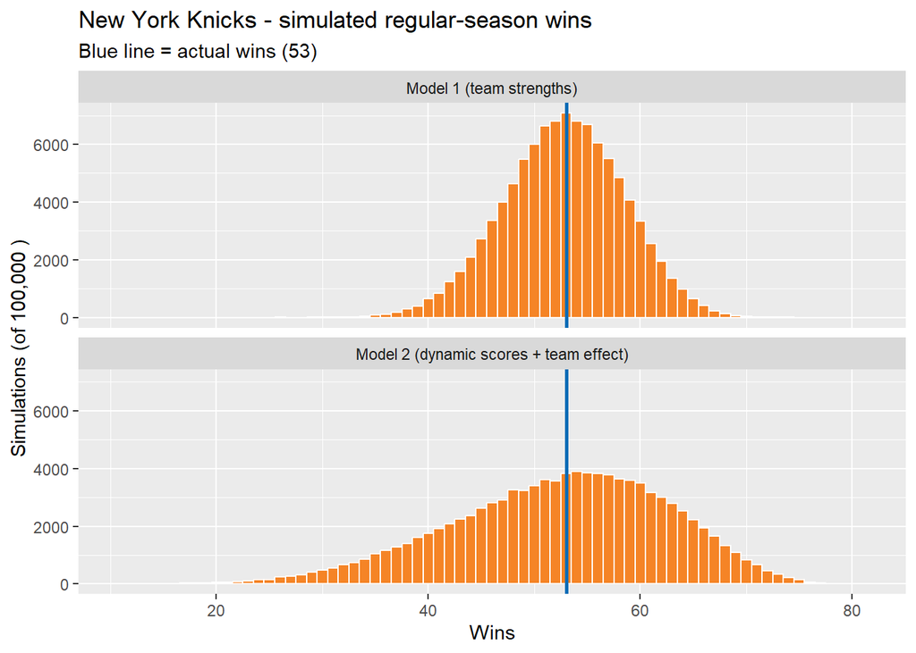

```r
ggplot(k_sims, aes(wins)) +
  geom_histogram(binwidth = 1, fill = "#F58426", colour = "white") +
  geom_vline(xintercept = k_actual$actual_wins, colour = "#006BB6", linewidth = 1) +
  facet_wrap(~model, ncol = 1) +
  labs(title = paste(FOCUS_TEAM, "- simulated regular-season wins"),
       subtitle = paste0("Blue line = actual wins (", k_actual$actual_wins, ")"),
       x = "Wins", y = paste("Simulations (of", comma(N_SIMS), ")"))
```

Next, the Knicks’ finishing position in the East. The blue triangle marks where they actually finished.

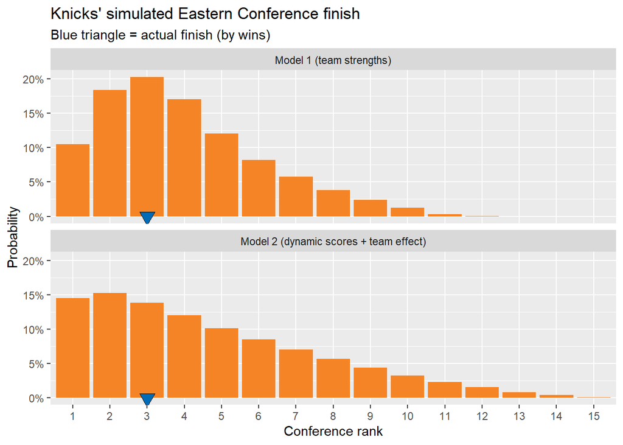

```r
k_sims |>
  count(model, conf_rank) |>
  mutate(p = n / N_SIMS) |>
  ggplot(aes(factor(conf_rank), p)) +
  geom_col(fill = "#F58426") +
  geom_point(data = tidyr::crossing(model = levels(sims$model), conf_rank = k_actual$actual_conf_rank) |>
               mutate(model = factor(model, levels = levels(sims$model)), p = 0),
             shape = 25, size = 4, fill = "#006BB6") +
  facet_wrap(~model, ncol = 1) +
  scale_y_continuous(labels = percent) +
  labs(title = "Knicks' simulated Eastern Conference finish",
       subtitle = "Blue triangle = actual finish (by wins)",
       x = "Conference rank", y = "Probability")
```

```r
knicks_summary <- function(d) {
  c(round(mean(d$wins), 1),
    percent(mean(d$wins >= k_actual$actual_wins), 0.1),
    round(mean(d$conf_rank), 2),
    names(which.max(table(d$conf_rank))),
    percent(mean(d$conf_rank == 1), 0.1),
    percent(mean(d$conf_rank <= 2), 0.1),
    percent(mean(!is.na(d$playoff_seed)), 0.1),
    percent(mean(d$rounds_won >= 3), 0.1),
    percent(mean(d$rounds_won == 4), 0.1))
}
tab <- sapply(split(k_sims, k_sims$model), knicks_summary)
rownames(tab) <- c("Mean simulated wins",
                   paste0("P(simulated wins >= actual ", k_actual$actual_wins, ")"),
                   "Mean simulated East rank", "Most likely East rank",
                   "P(East #1 seed)", "P(East top 2)", "P(make playoffs)",
                   "P(win the East)", "P(win the title)")
kable(tab, caption = paste0("Actual: ", k_actual$actual_wins, " wins, East rank ", k_actual$actual_conf_rank,
                            " (by wins; no tiebreakers)"))
```

Actual: 53 wins, East rank 3 (by wins; no tiebreakers)

|  | Model 1 (team strengths) | Model 2 (dynamic scores + team effect) |
| --- | --- | --- |
| Mean simulated wins | 52.8 | 52.3 |
| P(simulated wins >= actual 53) | 52.8% | 52.4% |
| Mean simulated East rank | 3.94 | 4.67 |
| Most likely East rank | 3 | 2 |
| P(East #1 seed) | 10.5% | 14.5% |
| P(East top 2) | 28.8% | 29.8% |
| P(make playoffs) | 95.6% | 87.5% |
| P(win the East) | 12.9% | 14.5% |
| P(win the title) | 3.2% | 6.6% |

**What to conclude.** Under Model 1 the Knicks average 52.8 wins per simulated season (standard deviation 5.7) and under Model 2 52.3 (standard deviation 10.2). Their actual 53 wins would be matched or exceeded in 52.8% and 52.4% of seasons, so the Knicks’ regular season was almost exactly what the models expected. That is not surprising, because the ratings are estimated from those same 82 games. Two lessons follow. First, a team’s win total moves by many games from one simulated season to the next even though its ratings never change, so a few games of difference in the standings is weak evidence of a difference in quality. Second, where the Knicks “should” have placed is a range, not a single seed. Their most likely finish is 3rd in the East under Model 1 (matching what happened) and 2nd under Model 2, with an average rank of 3.9 and 4.7. They finish in the top two in 28.8% and 29.8% of seasons, and finish first in 10.5% and 14.5%. Model 2’s seasons are much more spread out (a standard deviation of about 10 wins versus 5.7), which is also why it is less likely to have the Knicks make the playoffs at all (87.5% versus 95.6%). That extra spread is partly real uncertainty about the model’s own parameters and partly an artifact we discuss under Limitations.

## Results: Was the Title an Anomaly?

We now come to the central question. The next table gives each team’s chance of winning the championship in a season replayed under each model. With 100,000 replays, each probability is accurate to within about 0.2 percentage points (the standard error is at most 0.16 points).

```r
title_odds <- sims |>
  group_by(model, team, conf) |>
  summarise(mean_wins  = mean(wins),
            p_playoffs = mean(!is.na(playoff_seed)),
            p_finals   = mean(rounds_won >= 3),
            titles     = sum(rounds_won == 4),
            p_title    = titles / N_SIMS,
            se         = sqrt(p_title * (1 - p_title) / N_SIMS),
            .groups = "drop")

short <- c("M1", "M2")
title_wide <- title_odds |>
  select(team, model, mean_wins, p_title) |>
  mutate(model = short[as.integer(model)]) |>
  pivot_wider(names_from = model, values_from = c(mean_wins, p_title)) |>
  arrange(desc(p_title_M2))

bind_rows(slice_head(title_wide, n = 10), filter(title_wide, team == FOCUS_TEAM)) |>
  distinct() |>
  mutate(across(starts_with("mean_wins"), ~ round(.x, 1)),
         across(starts_with("p_title"), ~ percent(.x, 0.1))) |>
  kable(col.names = c("Team", paste0("Mean wins (", short, ")"), paste0("Title % (", short, ")")),
        caption = "Ten most likely champions (ranked by Model 2) plus the Knicks")
```

Ten most likely champions (ranked by Model 2) plus the Knicks

| Team | Mean wins (M1) | Mean wins (M2) | Title % (M1) | Title % (M2) |
| --- | --- | --- | --- | --- |
| Oklahoma City Thunder | 63.6 | 57.2 | 36.8% | 19.1% |
| San Antonio Spurs | 61.6 | 56.5 | 24.8% | 17.9% |
| Detroit Pistons | 59.7 | 56.8 | 16.8% | 15.0% |
| Boston Celtics | 55.7 | 55.0 | 7.2% | 13.1% |
| New York Knicks | 52.8 | 52.3 | 3.2% | 6.6% |
| Houston Rockets | 51.8 | 50.2 | 1.4% | 4.4% |
| Los Angeles Lakers | 52.8 | 50.4 | 2.1% | 4.1% |
| Charlotte Hornets | 43.9 | 47.9 | 0.2% | 3.0% |
| Cleveland Cavaliers | 51.8 | 47.9 | 2.4% | 2.9% |
| Denver Nuggets | 53.8 | 48.6 | 2.8% | 2.7% |

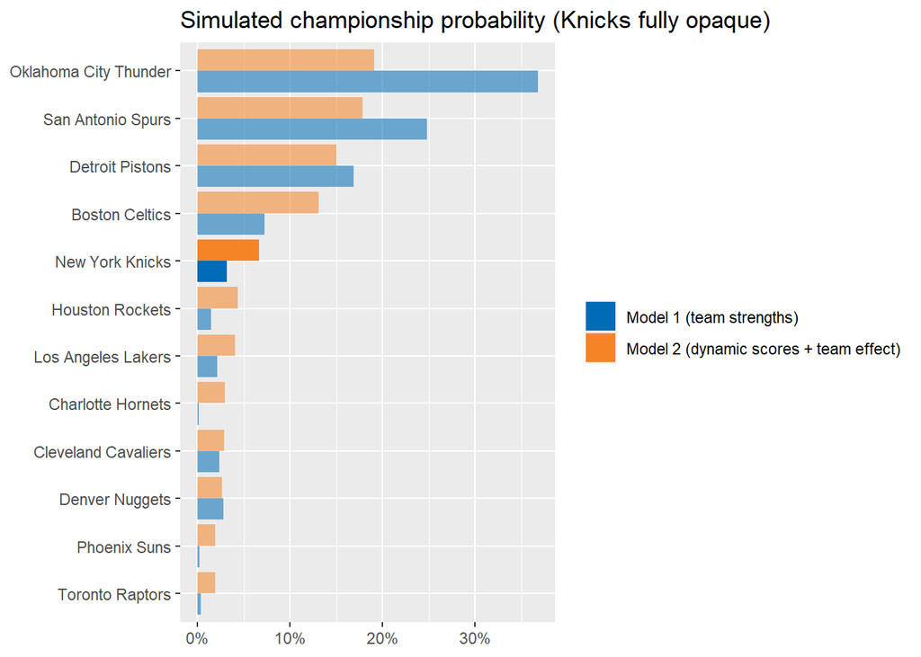

```r
top_teams <- title_odds |> group_by(team) |> summarise(m = max(p_title), .groups = "drop") |>
  slice_max(m, n = 12) |> pull(team)

title_odds |>
  filter(team %in% unique(c(top_teams, FOCUS_TEAM))) |>
  group_by(team) |> mutate(ord = max(p_title)) |> ungroup() |>
  mutate(team = reorder(team, ord), focus = team == FOCUS_TEAM) |>
  ggplot(aes(team, p_title, fill = model, alpha = focus)) +
  geom_col(position = "dodge") +
  scale_alpha_manual(values = c(`TRUE` = 1, `FALSE` = 0.55), guide = "none") +
  scale_fill_manual(values = c("#006BB6", "#F58426")) +
  scale_y_continuous(labels = percent) +
  coord_flip() +
  labs(title = "Simulated championship probability (Knicks fully opaque)", x = NULL, y = NULL, fill = NULL)
```

```r
anomaly <- title_odds |>
  group_by(model) |>
  mutate(rank = rank(-p_title, ties.method = "min")) |>
  summarise(
    p_knicks    = p_title[team == FOCUS_TEAM],
    rank_knicks = rank[team == FOCUS_TEAM],
    top_team    = team[which.max(p_title)],
    top_p       = max(p_title),
    # chance that a typical season's champion has title odds at or below the Knicks'
    p_longshot  = sum(p_title[p_title <= p_title[team == FOCUS_TEAM]]),
    .groups = "drop")

anomaly |>
  transmute(Model = model,
            `P(Knicks win title)` = percent(p_knicks, 0.1),
            `About 1 in` = round(1 / p_knicks),
            `Rank among 30 teams` = rank_knicks,
            `Most likely champion` = paste0(top_team, " (", percent(top_p, 0.1), ")"),
            `P(champion has title odds <= Knicks')` = percent(p_longshot, 0.1)) |>
  kable()
```

| Model | P(Knicks win title) | About 1 in | Rank among 30 teams | Most likely champion | P(champion has title odds <= Knicks’) |
| --- | --- | --- | --- | --- | --- |
| Model 1 (team strengths) | 3.2% | 31 | 5 | Oklahoma City Thunder (36.8%) | 14.4% |
| Model 2 (dynamic scores + team effect) | 6.6% | 15 | 5 | Oklahoma City Thunder (19.1%) | 34.9% |

**How to read the last column.** Suppose we repeatedly replay the season and look at who wins. The final column asks: how often is the champion a team whose title chances were no better than the Knicks’? If that number is large, then champions like the Knicks are ordinary. If it is tiny, a champion like the Knicks would be a genuine surprise. This is a better measure of an “anomaly” than the Knicks’ own title probability alone, because even the *favorite* in a 30-team league wins a small share of titles, so a small probability by itself does not mean the outcome was freakish.

**What to conclude.** Under Model 1 the Knicks rank 5th of 30 in title odds with a 3.2% chance (about 1 in 31). Under Model 2 they also rank 5th, with 6.6% (about 1 in 15). A champion with title odds as low as theirs appears in 14.4% (Model 1) and 34.9% (Model 2) of replayed seasons, roughly one season in seven to one in three. So a title for a team with the Knicks’ odds is uncommon but far from shocking. The Knicks were a top-five title contender under both models, not a team that came from nowhere, but they were also well behind the favorites, so the title was a long shot, not an anomaly. The simulated Knicks win the East in 12.9% (Model 1) and 14.5% (Model 2) of seasons, so winning the Finals as well required a further lucky step.

The two models disagree on how likely the Knicks were, and the reason is worth understanding. Model 2 rates the Knicks’ title chances about twice as high as Model 1 (6.6% versus 3.2%). Part of this is real: it sees a team with a very strong defense and good late-season form, which a plain win-loss rating does not capture. But part of it comes from Model 2 spreading title chances more evenly across the league, because its simulated seasons are less spread out between strong and weak teams than the real standings. Oklahoma City falls from 36.8% to 19.1%, San Antonio from 24.8% to 17.9%, and Detroit from 16.8% to 15.0%, while Boston (7.2% to 13.1%), Houston (1.4% to 4.4%), Charlotte (0.2% to 3.0%) and the Knicks all gain. We therefore treat 3.2% to 6.6% as a plausible range for the Knicks’ title chances.

### How the Knicks’ title chances depend on their seed

The Knicks’ own path depends on which seed they earn, since a better seed means a weaker first-round opponent and more home games. The table gives the Knicks’ title probability *given* each seed, in simulated seasons where they made the playoffs. The `Seasons` column shows how many simulated seasons landed on each seed, so rarer seeds have noisier estimates. Under Model 1, moving from the 3 seed to the 1 seed raises the Knicks’ title chance from 3.0% to 9.7%. Under Model 2 the effect is much larger (from 6.0% to 22.2%), because in that model a high seed usually signals that the Knicks’ scoring and defense were also strong going into the playoffs.

```r
k_sims |>
  filter(!is.na(playoff_seed)) |>
  group_by(Model = model, `Playoff seed` = playoff_seed) |>
  summarise(Seasons = n(),
            `P(win East)`  = percent(mean(rounds_won >= 3), 0.1),
            `P(win title)` = percent(mean(rounds_won == 4), 0.1), .groups = "drop") |>
  kable()
```

| Model | Playoff seed | Seasons | P(win East) | P(win title) |
| --- | --- | --- | --- | --- |
| Model 1 (team strengths) | 1 | 10466 | 31.7% | 9.7% |
| Model 1 (team strengths) | 2 | 18371 | 20.1% | 5.2% |
| Model 1 (team strengths) | 3 | 20293 | 12.9% | 3.0% |
| Model 1 (team strengths) | 4 | 17070 | 9.1% | 2.0% |
| Model 1 (team strengths) | 5 | 12057 | 6.9% | 1.3% |
| Model 1 (team strengths) | 6 | 8220 | 6.1% | 1.1% |
| Model 1 (team strengths) | 7 | 5484 | 4.5% | 0.9% |
| Model 1 (team strengths) | 8 | 3641 | 3.2% | 0.4% |
| Model 2 (dynamic scores + team effect) | 1 | 14528 | 42.8% | 22.2% |
| Model 2 (dynamic scores + team effect) | 2 | 15268 | 24.0% | 10.7% |
| Model 2 (dynamic scores + team effect) | 3 | 13831 | 14.5% | 6.0% |
| Model 2 (dynamic scores + team effect) | 4 | 12007 | 9.7% | 3.9% |
| Model 2 (dynamic scores + team effect) | 5 | 10167 | 6.4% | 2.2% |
| Model 2 (dynamic scores + team effect) | 6 | 8506 | 4.5% | 1.6% |
| Model 2 (dynamic scores + team effect) | 7 | 7314 | 3.7% | 1.0% |
| Model 2 (dynamic scores + team effect) | 8 | 5918 | 2.2% | 0.8% |

### Finals matchups

Because every simulation records the champion and runner-up, we can estimate joint events such as “Team A and Team B make the Finals and Team A wins”.

```r
finals <- sims |>
  filter(rounds_won >= 3) |>
  group_by(model, sim) |>
  summarise(champion = team[rounds_won == 4], runner_up = team[rounds_won == 3], .groups = "drop")

finals |>
  count(model, champion, runner_up, sort = TRUE) |>
  group_by(model) |> slice_head(n = 6) |> ungroup() |>
  mutate(p = percent(n / N_SIMS, 0.1)) |>
  select(Model = model, Champion = champion, `Runner-up` = runner_up, `P(this exact result)` = p) |>
  kable(caption = "Most common Finals results")
```

Most common Finals results

| Model | Champion | Runner-up | P(this exact result) |
| --- | --- | --- | --- |
| Model 1 (team strengths) | Oklahoma City Thunder | Detroit Pistons | 14.0% |
| Model 1 (team strengths) | San Antonio Spurs | Detroit Pistons | 9.3% |
| Model 1 (team strengths) | Oklahoma City Thunder | Boston Celtics | 8.7% |
| Model 1 (team strengths) | Detroit Pistons | Oklahoma City Thunder | 6.6% |
| Model 1 (team strengths) | San Antonio Spurs | Boston Celtics | 5.8% |
| Model 1 (team strengths) | Detroit Pistons | San Antonio Spurs | 5.7% |
| Model 2 (dynamic scores + team effect) | Oklahoma City Thunder | Detroit Pistons | 4.9% |
| Model 2 (dynamic scores + team effect) | San Antonio Spurs | Detroit Pistons | 4.5% |
| Model 2 (dynamic scores + team effect) | Oklahoma City Thunder | Boston Celtics | 4.5% |
| Model 2 (dynamic scores + team effect) | San Antonio Spurs | Boston Celtics | 4.0% |
| Model 2 (dynamic scores + team effect) | Detroit Pistons | Oklahoma City Thunder | 3.9% |
| Model 2 (dynamic scores + team effect) | Detroit Pistons | San Antonio Spurs | 3.9% |

When the Knicks do win the title, the following table shows whom they beat in the Finals (the share of Knicks titles).

```r
finals |>
  filter(champion == FOCUS_TEAM) |>
  count(model, runner_up) |>
  group_by(model) |> mutate(`Share of Knicks titles` = percent(n / sum(n), 0.1)) |>
  slice_max(n, n = 5) |> ungroup() |>
  select(Model = model, `Runner-up` = runner_up, Titles = n, `Share of Knicks titles`) |>
  kable()
```

| Model | Runner-up | Titles | Share of Knicks titles |
| --- | --- | --- | --- |
| Model 1 (team strengths) | Oklahoma City Thunder | 1163 | 36.2% |
| Model 1 (team strengths) | San Antonio Spurs | 1038 | 32.3% |
| Model 1 (team strengths) | Denver Nuggets | 349 | 10.9% |
| Model 1 (team strengths) | Los Angeles Lakers | 274 | 8.5% |
| Model 1 (team strengths) | Houston Rockets | 204 | 6.4% |
| Model 2 (dynamic scores + team effect) | San Antonio Spurs | 1716 | 25.9% |
| Model 2 (dynamic scores + team effect) | Oklahoma City Thunder | 1658 | 25.0% |
| Model 2 (dynamic scores + team effect) | Houston Rockets | 769 | 11.6% |
| Model 2 (dynamic scores + team effect) | Los Angeles Lakers | 686 | 10.4% |
| Model 2 (dynamic scores + team effect) | Denver Nuggets | 442 | 6.7% |

The most common Finals results all involve the teams with the strongest ratings, and each single exact matchup has a small probability because there are many possible Finals pairings. A Knicks title typically comes against the strongest Western Conference team: under Model 2 the runner-up is San Antonio in 25.9% of Knicks titles and Oklahoma City in 25.0%. The Knicks’ Eastern Conference opponents have already been eliminated by the time they reach the Finals. Under Model 2 the single most likely Finals result is Oklahoma City beating Detroit, at only 4.9%, which shows how spread out the outcomes are.

### A simulated season in detail

To make these numbers concrete, here is the first simulated season in which the Knicks won the championship under each model.

```r
ex <- k_sims |>
  filter(rounds_won == 4) |>
  group_by(model) |> slice_head(n = 1) |> ungroup() |>
  left_join(finals |> select(model, sim, runner_up), by = c("model", "sim")) |>
  transmute(Model = model, `Simulation #` = sim, `Knicks wins` = wins,
            `East rank` = conf_rank, `Playoff seed` = playoff_seed, `Beat in Finals` = runner_up)
kable(ex)
```

| Model | Simulation # | Knicks wins | East rank | Playoff seed | Beat in Finals |
| --- | --- | --- | --- | --- | --- |
| Model 1 (team strengths) | 16 | 66 | 1 | 1 | San Antonio Spurs |
| Model 2 (dynamic scores + team effect) | 27 | 68 | 1 | 1 | Phoenix Suns |

## Results: Which Teams Beat or Missed Expectations?

Finally, we look at the whole league. For each team, we compare its actual win total with the average of its simulated win totals, and we compute how often a simulated season gives the team at least as many wins as it actually had. A team with very few simulated seasons at or above its actual total won more games than the model expected (a “lucky” or over-performing team); a team with most simulated seasons above its actual total won fewer.

```r
perf <- sims |>
  left_join(actual |> select(team, actual_wins), by = "team") |>
  group_by(model, team) |>
  summarise(actual = first(actual_wins), simulated = mean(wins), sd_wins = sd(wins),
            p_ge = mean(wins >= first(actual_wins)), .groups = "drop") |>
  mutate(diff = actual - simulated)

bind_rows(
  perf |> group_by(Model = as.character(model)) |>
    summarise(`Correlation with actual wins` = round(cor(simulated, actual), 3),
              `Typical error (wins)`          = round(sqrt(mean(diff^2)), 1),
              `Best-to-worst gap in mean wins` = round(diff(range(simulated)), 1),
              `Typical SD of a team's wins`   = round(mean(sd_wins), 1), .groups = "drop"),
  tibble(Model = "Actual 2025-26 season", `Correlation with actual wins` = 1, `Typical error (wins)` = 0,
         `Best-to-worst gap in mean wins` = diff(range(actual$actual_wins)),
         `Typical SD of a team's wins` = NA_real_)) |>
  kable(caption = "How closely each model's simulated seasons track the real standings")
```

How closely each model’s simulated seasons track the real standings

| Model | Correlation with actual wins | Typical error (wins) | Best-to-worst gap in mean wins | Typical SD of a team’s wins |
| --- | --- | --- | --- | --- |
| Model 1 (team strengths) | 1.000 | 0.2 | 46.2 | 5.6 |
| Model 2 (dynamic scores + team effect) | 0.981 | 3.8 | 34.6 | 10.2 |
| Actual 2025-26 season | 1.000 | 0.0 | 47.0 | NA |

```r
perf_tbl <- function(m) {
  d <- perf |> filter(model == m) |> arrange(desc(diff))
  bind_rows(slice_head(d, n = 5), slice_tail(d, n = 5)) |>
    transmute(Team = team, `Actual wins` = actual, `Mean simulated wins` = round(simulated, 1),
              Difference = round(diff, 1), `P(simulated >= actual)` = percent(p_ge, 1))
}
kable(perf_tbl(levels(sims$model)[2]),
      caption = "Model 2: five teams that most exceeded and five that most fell short of simulated wins")
```

Model 2: five teams that most exceeded and five that most fell short of simulated wins

| Team | Actual wins | Mean simulated wins | Difference | P(simulated >= actual) |
| --- | --- | --- | --- | --- |
| Oklahoma City Thunder | 64 | 57.2 | 6.8 | 28% |
| Miami Heat | 43 | 37.3 | 5.7 | 32% |
| San Antonio Spurs | 62 | 56.5 | 5.5 | 33% |
| Denver Nuggets | 54 | 48.6 | 5.4 | 35% |
| Cleveland Cavaliers | 52 | 47.9 | 4.1 | 39% |
| New Orleans Pelicans | 26 | 30.7 | -4.7 | 67% |
| Sacramento Kings | 22 | 27.3 | -5.3 | 69% |
| Washington Wizards | 17 | 22.5 | -5.5 | 72% |
| Indiana Pacers | 19 | 25.4 | -6.4 | 75% |
| Brooklyn Nets | 20 | 27.6 | -7.6 | 77% |

The first table checks how closely each model’s simulated seasons track the real standings. Model 1 matches them almost exactly by construction. Model 2 does not: its correlation with actual wins is 0.981 and its typical error is 3.8 wins. It is also compressed. The best-to-worst gap in average wins is 34.6 games versus an actual 47.0, because rating a team from noisy, recent scoring averages pulls the strongest teams toward average and the weakest up.

The second table lists the teams furthest from their Model 2 expectation. Oklahoma City won 64 games against 57.2 simulated (+6.8), Miami 43 versus 37.3 (+5.7), and San Antonio (+5.5) and Denver (+5.4) were also well above expectation. Brooklyn fell shortest (20 wins against 27.6 simulated, −7.6), followed by Indiana (−6.4) and Washington (−5.5). The Knicks’ own gap was only +0.7 wins (53 actual versus 52.3). These gaps are a mix of luck, quality that scoring does not capture, and the compression described above, which is why the biggest gaps are mostly at the extremes of the standings.

### How often does each team land each playoff seed?

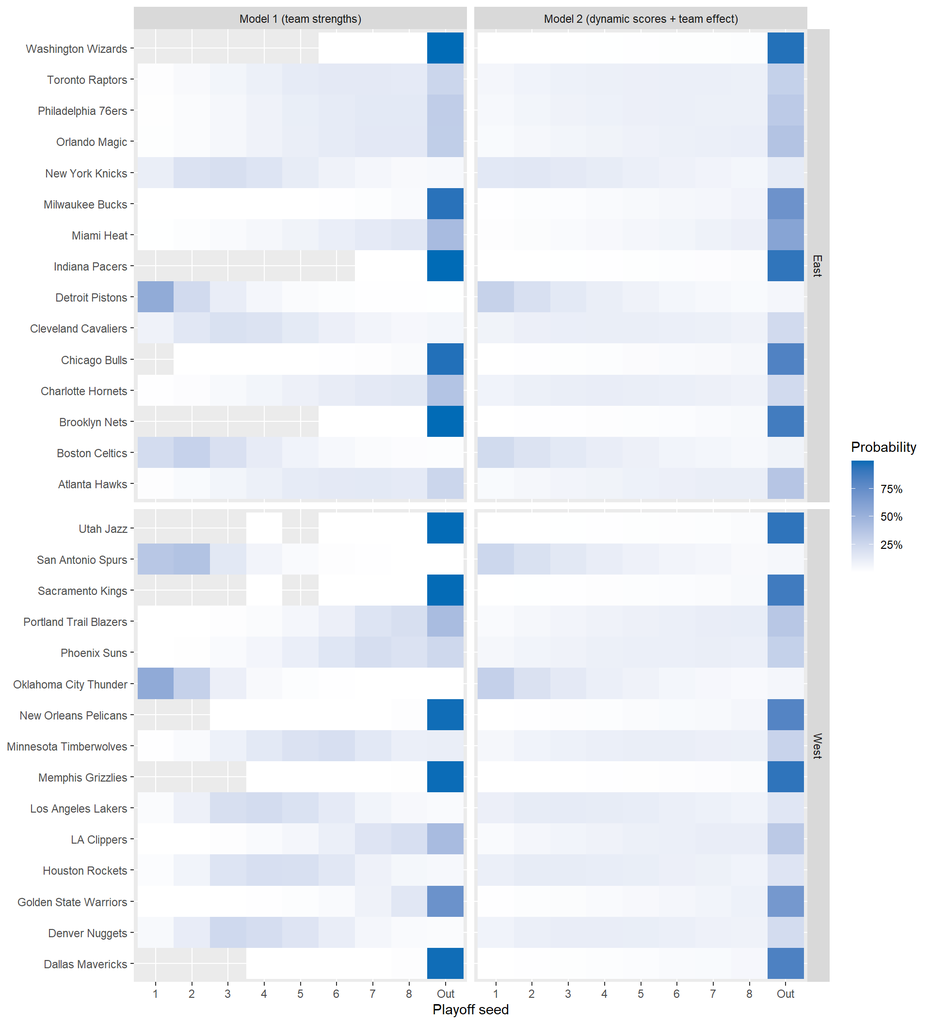

```r
sims |>
  mutate(seed_lab = factor(if_else(is.na(playoff_seed), "Out", as.character(playoff_seed)),
                           levels = c(as.character(1:8), "Out"))) |>
  count(model, team, conf, seed_lab) |>
  mutate(p = n / N_SIMS) |>
  ggplot(aes(seed_lab, team, fill = p)) +
  geom_tile() +
  scale_fill_gradient(low = "white", high = "#006BB6", labels = percent) +
  facet_grid(conf ~ model, scales = "free_y") +
  labs(x = "Playoff seed", y = NULL, fill = "Probability")
```

The Knicks’ most likely outcome is the 3 seed under Model 1 (their actual seed) and the 2 seed under Model 2. Their row is spread across several seeds, which shows how wide the range of plausible outcomes is for them, and it is wider under Model 2 than Model 1. Under Model 2 they miss the playoffs entirely in 12.5% of seasons, compared with 4.4% under Model 1.

## Limitations and Future Work

- **Final scores only.** Offensive and defensive scores are points per game relative to the league, so fast- and slow-paced teams are not separated, and opponent strength is not adjusted for. Team box scores would let us use per-possession efficiency, which is a cleaner measure of quality.
- **No injuries, trades, or rest.** Both models assume a team’s quality changes only through its scoring (and, in Model 2, a fixed team effect). A star injury in the playoffs would change a team’s title chances in a way neither model can capture.
- **Model 2’s simulated seasons are compressed and too variable.** The error against actual team wins is a typical 3.8 games, the best-to-worst gap in average wins is 34.6 versus an actual 47, and a typical team’s win total has a standard deviation of 10.2 games versus 5.6 under Model 1. Much of this extra spread comes from carrying parameter uncertainty through the points model. Model 2’s title odds should therefore be read as flatter than they would be with a fully calibrated model. Using a shrinkage prior on the scoring coefficients or fitting the points and win models jointly are natural fixes.
- **The playoff updating is unvalidated.** Model 2 updates scores after every simulated playoff game, but we have no way to check against real playoff data that this momentum is real. In an earlier test that switched this updating on for a model without team effects, title chances moved by less than two percentage points for any team, so we do not expect our conclusions to depend on it.
- **The points model is fitted in-sample.** Each team’s “true” scoring level used to generate points in the simulation comes from a model fit to the full season, so it is an in-sample estimate. Parameter uncertainty partly accounts for this.
- **Tuning constants** (`HALF_LIFE` and `PRIOR_GAMES`) were chosen by judgment, not optimized. Future work could choose them by held-out log-loss.
- **Seeding rules are simplified**: ties are broken at random rather than with the NBA’s official tiebreakers, and home-court advantage is one league-wide number, also used in the playoffs.
- **Model 2’s team effects are estimated with an approximate method** (penalized quasi-likelihood, as in `BTm`), and their uncertainty in the simulation uses a normal approximation. A fully Bayesian fit would handle both more carefully.

## Reproducing This Work

Install the packages `dplyr`, `tidyr`, `ggplot2`, `scales`, `knitr`, `tibble`, `readr`, `BradleyTerry2`, and `hoopR`. Render `09_project.qmd` with `quarto render 09_project.qmd` (HTML) or `quarto render 09_project.qmd --to pdf`. The schedule is loaded from `data/nba_games.csv` (or downloaded live from `hoopR` when `GAMES_CSV <- NULL`). The simulations for both models are saved to `data/nba_sims_2026.rds` the first time and reloaded afterward (they are re-run automatically if `N_SIMS` or the models change) unless `RERUN_SIMS <- FALSE` is changed to `TRUE`. The seed (`SEED = 2026`) is set before each model’s simulations, so the results in the text can be reproduced exactly. The numbers quoted in the written text come from a run on the schedule data as downloaded in early November 2026. If ESPN later revises scores, small differences are possible, and the text would need to be updated to match.